# R Notebook excercise – BIOS259

Aziz Khan

Stanford University, CA, USA

18 March 2024

Abstract

This is hands-on excrcise for BIOS 259: The Art of Reproducible Science – a Stanford Biosciences mini-course on computational reproducibility

## Introduction

In this **R Notebook**, we’ll explore some built-in datasets in R base and create visualizations to analyze the data. The goal is to demonstrate how R Markdown combines code and narrative text to produce *reproducible research*.

## Load Data

We’ll start by loading the `iris` dataset, which contains measurements of iris flowers.

```r
# Load the iris dataset
data(iris)
head(iris)
```

|  | Sepal.Length | Sepal.Width | Petal.Length | Petal.Width | Species |
| --- | --- | --- | --- | --- | --- |
| 1 | 5.1 | 3.5 | 1.4 | 0.2 | setosa |
| 2 | 4.9 | 3.0 | 1.4 | 0.2 | setosa |
| 3 | 4.7 | 3.2 | 1.3 | 0.2 | setosa |
| 4 | 4.6 | 3.1 | 1.5 | 0.2 | setosa |
| 5 | 5.0 | 3.6 | 1.4 | 0.2 | setosa |
| 6 | 5.4 | 3.9 | 1.7 | 0.4 | setosa |

The iris dataset contains measurements of sepal length, sepal width, petal length, and petal width for **3 species** of iris flowers: setosa, versicolor, and virginica.

## Summary Statistics

Let’s explore the structure of the iris dataset and summary statistics for each variable.

```r
# Explore dataset structure
str(iris)
```

```
'data.frame':   150 obs. of  5 variables:
 $ Sepal.Length: num  5.1 4.9 4.7 4.6 5 5.4 4.6 5 4.4 4.9 ...
 $ Sepal.Width : num  3.5 3 3.2 3.1 3.6 3.9 3.4 3.4 2.9 3.1 ...
 $ Petal.Length: num  1.4 1.4 1.3 1.5 1.4 1.7 1.4 1.5 1.4 1.5 ...
 $ Petal.Width : num  0.2 0.2 0.2 0.2 0.2 0.4 0.3 0.2 0.2 0.1 ...
 $ Species     : Factor w/ 3 levels "setosa","versicolor",..: 1 1 1 1 1 1 1 1 1 1 ...
```

```r
# Summary statistics
summary(iris)
```

```
  Sepal.Length    Sepal.Width     Petal.Length    Petal.Width          Species
 Min.   :4.300   Min.   :2.000   Min.   :1.000   Min.   :0.100   setosa    :50
 1st Qu.:5.100   1st Qu.:2.800   1st Qu.:1.600   1st Qu.:0.300   versicolor:50
 Median :5.800   Median :3.000   Median :4.350   Median :1.300   virginica :50
 Mean   :5.843   Mean   :3.057   Mean   :3.758   Mean   :1.199
 3rd Qu.:6.400   3rd Qu.:3.300   3rd Qu.:5.100   3rd Qu.:1.800
 Max.   :7.900   Max.   :4.400   Max.   :6.900   Max.   :2.500
```

## Data Visualization

### Scatter Plot

We’ll create a scatter plot to visualize the relationship between sepal length and sepal width for each species of iris flowers.

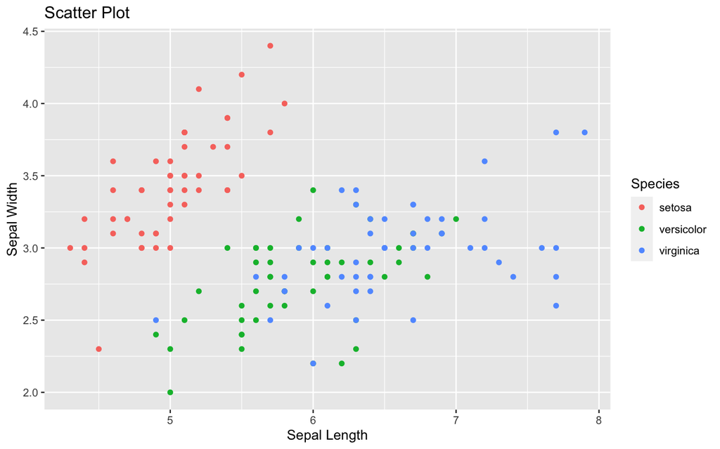

```r
# Scatter plot of sepal length vs. sepal width
library(ggplot2)
iris_scatter_plot <- ggplot(iris, aes(x = Sepal.Length, y = Sepal.Width, color = Species)) +
  geom_point() +
  labs(title = "Scatter Plot",
       x = "Sepal Length", y = "Sepal Width")

# print the plot
iris_scatter_plot
```

### Make the plot publication ready

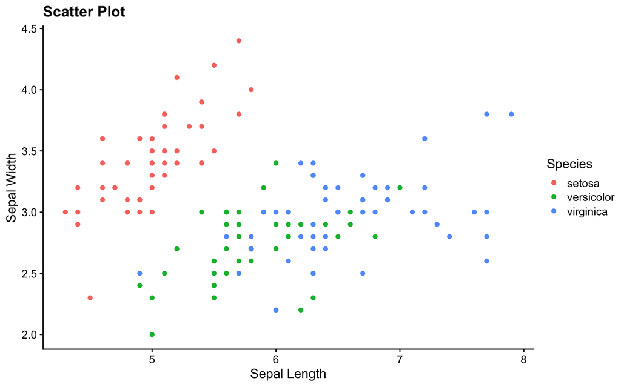

```r
# Load the cowplot
require(cowplot)
# Use the theme from cowplot
iris_scatter_plot <- iris_scatter_plot + theme_cowplot(12)
iris_scatter_plot
```

### Boxplot

Next, we’ll create a boxplot to compare the distribution of petal lengths for each species of iris flowers.

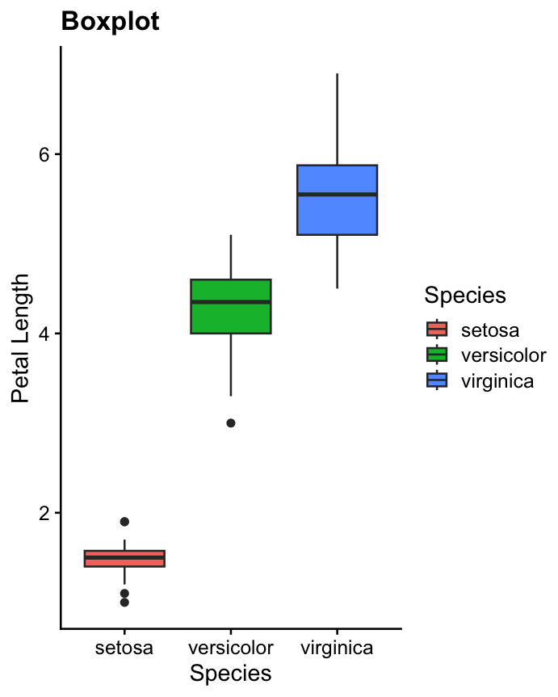

```r
# Boxplot of petal length by species
iris_box_plot <- ggplot(iris, aes(x = Species, y = Petal.Length, fill = Species)) +
  geom_boxplot() +
  labs(title = "Boxplot",
       x = "Species", y = "Petal Length") + theme_cowplot(12)

iris_box_plot
```

### Density Plot

Finally, let’s add a density plot to visualize the distribution of sepal lengths for each species of iris flowers.

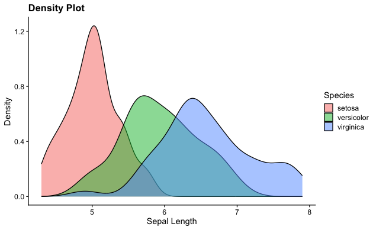

```r
# Density plot of sepal length by species
iris_density_plot <- ggplot(iris, aes(x = Sepal.Length, fill = Species)) +
  geom_density(alpha = 0.5) +
  labs(title = "Density Plot",
       x = "Sepal Length", y = "Density") + theme_cowplot(12)
iris_density_plot
```

## Conclusion

In this R Markdown document, we explored the iris dataset available in R base and created visualizations to analyze the data. By combining code and narrative text in R Markdown, we produced a reproducible analysis that can be easily shared and reproduced by others.

The `cowplot` package provides the function `plot_grid()` to arrange plots into a grid and label them.

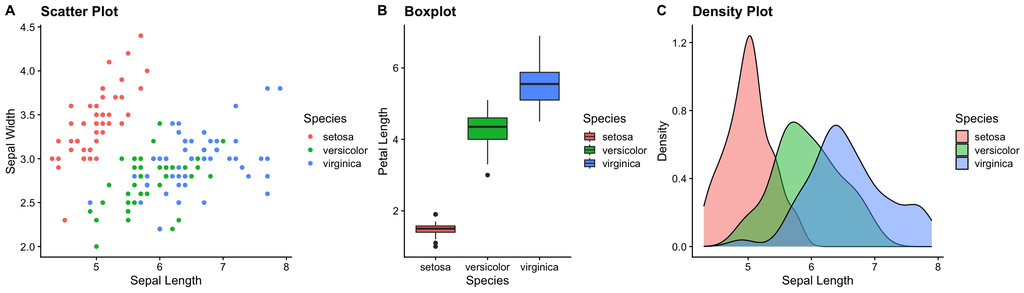

```r
#Arranging plots into a grid
plot_grid(iris_scatter_plot, iris_box_plot, iris_density_plot, labels = c('A', 'B','C'),
          ncol=3, rel_widths = c(2,1.5,2))
```

Feel free to modify the code, explore other datasets, or add additional visualizations to further analyze the data!

> **Note:** To generate publication ready figures you can try [ggpubr](https://rpkgs.datanovia.com/ggpubr/index.html)